# Exploring the Relationship Between Hip Hypermobility and Psychosocial Outcomes

Statistical Modeling

Shiny Apps

Clinical Data

Author

Will Schneider & Ellen Taylor

Published

December 18, 2024

## Executive Summary

Joint hypermobility, measured using the Beighton Score, has long been linked to greater incidence of injury and, indirectly, to psychosocial outcomes. However, the direct association between hypermobility and psychosocial symptoms (such as pain catastrophizing, pain interference, and pain self‑efficacy) remains underexplored.

In this analysis, we examined 445 hip clinic patients, using multiple linear and logistic regression models to assess relationships between hypermobility and psychosocial outcomes. Contrary to expectations, psychosocial variables had minimal influence on hypermobility. Age and gender were the primary predictors, with younger females exhibiting higher scores.

*Full results, reproducible code, and an interactive Shiny application are available [here](https://schneiderstats.shinyapps.io/hypermobility_app/).*

### What to Expect

This post proceeds in five steps: Data (who and what we measured), Methods (regression and imputation workflow), Results (key tables and plots), Discussion (clinical and methodological take‑aways), and Reproducibility (Shiny app + session info). Feel free to skip to any section of interest.

## Introduction

Joint hypermobility (JHM) is characterized by an increased range of motion in joints and measured in this context by the Beighton Score (0‑9 scale). Clinical guidelines often dichotomize this score (≥4 = hypermobile), but this practice is debated, as it may reduce statistical power and obscure data nuance.

Three psychosocial domains are explored:

- **Pain Catastrophizing** (PCS): Tendency to magnify or ruminate on pain.
- **Pain Interference** (PROMIS‑PI): Degree to which pain disrupts daily activities.
- **Pain Self‑Efficacy** (PSEQ): Belief in ability to manage pain.

Our study sought to answer:

**How does hypermobility relate to psychosocial outcomes?**

We hypothesized that patients with greater hypermobility would exhibit higher pain catastrophizing/interference and lower self‑efficacy.

## Methods

### Participants

- **N = 445** patients from a Baylor Scott & White hip clinic.
- Beighton Score, age, gender, and three psychosocial surveys (PCS, PROMIS‑PI, PSEQ) collected.

### Data Exploration and Visualization

- Outcome variable (Beighton Score) and psychosocial predictors were all treated as continuous.
- Missing data: Substantial missingness in PCS, PROMIS‑PI, PSEQ (see Table 3).
- No missingness in Beighton, age, or gender.

#### Summary Table: Demographics

Patient Characteristics (N=445)

| Variable | mean(sd) |
| --- | --- |
| Female n(%) | 343(0.77) |
| Age | 40.9(16.47) |
| Beighton Score | 3.8(3.2) |
| Pain Catastrophizing Score | 20.3(13.5) |
| Pain Interference Score | 63.0(70.2) |
| Pain Self-efficacy Score | 6.0(3.5) |

<sup>a</sup> All variables are mean (SD) unless otherwise noted.

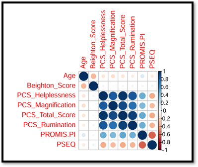

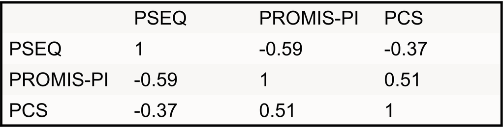

### Handling Missing Data

**Key challenge:** Substantial missingness (47–64 %) in psychosocial variables.

- Solution: Multiple Imputation by Chained Equations (MICE).
- Imputation count based on highest fraction of missing information (FMI).

#### Table: Missing Data

| Variable | n missing | Proportion missing | FMI |
| --- | --- | --- | --- |
| Pain Catastrophizing Score | 250 | 0.56 | 0.68 |
| Pain Interference Score | 286 | 0.64 | 0.86 |
| Pain Self‑Efficacy Score | 210 | 0.47 | 0.68 |

[figure not shown]

**Reading the plot.**  
*The bar chart confirms **PROMIS‑PI** has the most missing values (~64 %), followed by **PCS** (~56 %) and **PSEQ** (~47 %). In the heat‑map, each row is a patient; **red = missing**, **blue = observed**. Red blocks appear in no obvious vertical stripe, so missingness is not monotone and is plausibly **Missing at Random (MAR)**—a prerequisite for using MICE. Only the right‑hand side “combo” bars show a tiny subset with complete psychosocial data, justifying why imputation is essential.*

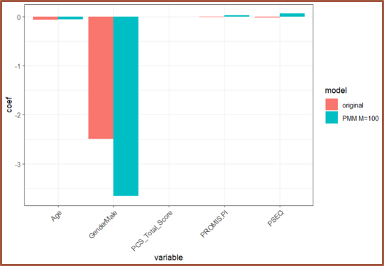

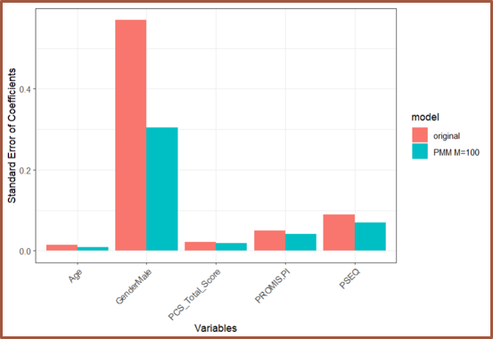

## Statistical Analysis

- Multiple Linear Regression (MLR) on complete cases and imputed data.
- Post‑hoc Logistic Regression: Beighton dichotomized (≥4 vs <4).
- All models included age and gender as covariates.
- Multicollinearity checked (VIF < 2 for all predictors).
- Diagnostic plots confirmed assumptions.

## Results

Regression Results

| Term | Complete Cases MLR | Multiple Imputation MLR | Multiple Imputation Logistic Regression |
| --- | --- | --- | --- |
| (Intercept) | 6.791 | 5.693 | 2.313 |
|  | (0.043) | (0.009) | (0.205) |
| Age | -0.060 | -0.059 | -0.054 |
|  | (<0.001) | (<0.001) | (<0.001) |
| GenderMale | -2.495 | -3.703 | -2.987 |
|  | (<0.001) | (<0.001) | (<0.001) |
| Pain Catastrophizing Score | 0.001 | -0.003 | -0.005 |
|  | (0.980) | (0.833) | (0.707) |
| Pain Interference Score | -0.011 | 0.021 | 0.014 |
|  | (0.829) | (0.496) | (0.610) |
| Pain Self-efficacy Score | -0.018 | 0.018 | 0.006 |
|  | (0.839) | (0.769) | (0.912) |

<sup>a</sup> The first row for each variable is the estimate, and the value below in parentheses is the p-value for the corresponding estimate.

### Key Findings

- **Age** and **gender** were the only significant predictors of hypermobility.
  - Each additional year = ≈ ‑0.06 Beighton points.
  - Males scored ≈ 3.7 points lower than females.
- **No significant effect** for any psychosocial variable (PCS, PROMIS‑PI, PSEQ) in any model.
- Imputed models yielded narrower standard errors vs complete‑case models.
- **Practical magnitude**: a ‑0.06 slope means a 10‑year age difference translates to ≈0.6 fewer Beighton points, so an otherwise identical 20‑ vs 30‑year‑old would differ by more than half a point.

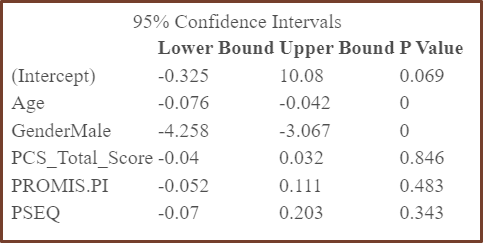

*All 95 % confidence intervals for PCS, PROMIS‑PI and PSEQ straddle 0, underscoring the statistical non‑significance of these psychosocial predictors.*

*Visual diagnostics (coefficients, SEs, and CIs) all tell the same story: Age ↓ and Female ↑ are the only stable predictors of hypermobility; psychosocial scores add no explanatory power*

## Discussion

- Psychosocial variables showed no statistically significant relationship with hypermobility.
- Age/gender effects robust across missing‑data handling methods.
- Findings align with literature: younger females exhibit greater hypermobility. ### Limitations
  1. **Data quality** – 47–64% missingness in psychosocial scores despite MICE.
  2. **Sampling frame** – clinic patients already in pain, so hypermobility’s incremental effect may be muted.
  3. **External validity** – results may not extend to general populations or non‑hip conditions.

### Recommendations

- **Clinicians:** Psychosocial screening may not enhance hypermobility risk assessment in a clinic population.
- **Researchers:** Examine general‑population samples to clarify psychosocial impacts of hypermobility.

## Interactive App

All analyses can be reproduced via our [Shiny app](https://schneiderstats.shinyapps.io/hypermobility_app/), which allows data upload, imputation, visualization, and regression without coding.

## References

*Full references available in the original report and slides. Key sources include:*

- Amtmann, Dagmar, Karon F Cook, Mark P Jensen, Wen-Hung Chen, Seung Choi, Dennis Revicki, David Cella, et al. 2010. “Development of a PROMIS Item Bank to Measure Pain Interference.” Pain 150 (1): 173–82.
- Hampton, SN, PA Nakonezny, HM Richard, and JE Wells. 2019. “Pain Catastrophizing, Anxiety, and Depression in Hip Pathology.” The Bone & Joint Journal 101 (7): 800–807.
- Schmidt, Amand F., and Chris Finan. 2018. “Linear Regression and the Normality Assumption.” Journal of Clinical Epidemiology 98: 146–51.https://doi.org/https://doi.org/10.1016/j.jclinepi.2017.12.006.